# Group 5 Report

Dagfinn, Mathilde, Joanna, Ingvild

2023-09-15

Load library

Read file

## Description of data

### Description of the dataset

The data is collcted from a randomized controlled trial (RCT). The objective of the RCT trial was to determine whether treatment of maternal periodontal disease can reduce risk of preterm birth and low birth weight.

The data in this script is primarily extracted from the exam_data.txt file, and subsequently joined with exam_data_join.txt. Data exploration was performed using functions like summary(), glimpse(), and View().

After removing one duplicate row, the dataset consisted of 834 subjects.

An additional dataset (exam_data_join.txt) was imported and joined with the main dataset based on the Patient ID (PID).

## Tidying and wrangling data

Several variables are renamed for clarity and consistency.

1. The column Local_Topical.Anest which had combined variables, is separated into two distinct variables: LocalAnesthetic and TopicalAnesthetic.
2. One duplicate entry was removed
3. The C column is transformed to have values “C” or “T” and subsequently renamed to “Group”.
4. Unwanted columns like year, month, and T are removed.
5. Values in the Education column are modified for clarity, removing “yrs” and replacing “MT” and “LT” with “>” and “<” respectively.
5. Boolean columns are created or modified, transforming string values like “Yes” and “No” to TRUE and FALSE respectively.
6. New columns are derived, such as one indicating if the number of qualifying teeth is less than 15.
7. The PID is separated to also include the enrollment center.
8. Variables like BMI are grouped into quartiles.
9. In total, 140 participants identified with multiple racial categories. For those who selected only one category, the options were consolidated to ‘White’, ‘Black’, ‘Nat.Am’, ‘Asian’, and ‘Hisp’. Participants who identified with more than one category were categorized as ‘Mixed’.
10. Lastly, the dataset was organized in ascending order based on patient ID, and the refined data was saved as ‘tidy_exam_data.txt’. All subsequent analyses were conducted using this dataset.

## Exploring data

```r
summary(OurData)
```

```
##      PID            Enroll.Center         Group                BMI
##  Length:834         Length:834         Length:834         Min.   :15.00
##  Class :character   Class :character   Class :character   1st Qu.:23.00
##  Mode  :character   Mode  :character   Mode  :character   Median :26.00
##                                                           Mean   :27.67
##                                                           3rd Qu.:31.00
##                                                           Max.   :68.00
##                                                           NA's   :75
##       Age          Black           White           Nat.Am
##  Min.   :16.00   Mode :logical   Mode :logical   Mode :logical
##  1st Qu.:22.00   FALSE:457       FALSE:596       FALSE:579
##  Median :25.00   TRUE :377       TRUE :238       TRUE :255
##  Mean   :26.02
##  3rd Qu.:30.00
##  Max.   :44.00
##
##    Asian            Hisp          Education         Hypertension
##  Mode :logical   Mode :logical   Length:834         Mode :logical
##  FALSE:827       FALSE:333       Class :character   FALSE:809
##  TRUE :7         TRUE :355       Mode  :character   TRUE :25
##                  NA's :146
##
##
##
##   Diabetes       BL.Diab.Type         Tx.comp.            Tx.time
##  Mode :logical   Length:834         Length:834         Min.   :0.1167
##  FALSE:810       Class :character   Class :character   1st Qu.:1.4167
##  TRUE :24        Mode  :character   Mode  :character   Median :2.1667
##                                                        Mean   :2.1877
##                                                        3rd Qu.:2.7500
##                                                        Max.   :5.8333
##                                                        NA's   :433
##  EDC.necessary.  Completed.EDC   N.extractions     N.perm.restorations
##  Mode :logical   Mode :logical   Min.   : 0.0000   Min.   : 0.000
##  FALSE:321       FALSE:133       1st Qu.: 0.0000   1st Qu.: 0.000
##  TRUE :491       TRUE :358       Median : 0.0000   Median : 1.000
##  NA's :22        NA's :343       Mean   : 0.9077   Mean   : 1.912
##                                  3rd Qu.: 1.0000   3rd Qu.: 3.000
##                                  Max.   :20.0000   Max.   :18.000
##                                  NA's   :379       NA's   :379
```

[output cut: 9 more lines]

```
##  Min.   : 101   Mode :logical   Mode :logical     Min.   :   4.90
##  1st Qu.:2964   FALSE:272       FALSE:185         1st Qu.:   4.90
##  Median :3270   TRUE :147       TRUE :234         Median :   4.90
##  Mean   :3205   NA's :415       NA's :415         Mean   :  17.41
##  3rd Qu.:3581                                     3rd Qu.:   6.90
##  Max.   :5160                                     Max.   :1291.07
##  NA's   :14                                       NA's   :28
##   IL8_baseline    NoQualTeeth<15  BMI_Quartile           race
##  Min.   : 1.200   Min.   :0.000   Length:834         Length:834
##  1st Qu.: 1.200   1st Qu.:0.000   Class :character   Class :character
##  Median : 1.200   Median :0.000   Mode  :character   Mode  :character
##  Mean   : 2.643   Mean   :0.452
##  3rd Qu.: 1.200   3rd Qu.:1.000
##  Max.   :73.320   Max.   :1.000
##  NA's   :28
```

```r
skimr::skim(OurData)
```

Data summary

| Name | OurData |
| --- | --- |
| Number of rows | 834 |
| Number of columns | 32 |
| _______________________ |  |
| Column type frequency: |  |
| character | 9 |
| logical | 12 |
| numeric | 11 |
| ________________________ |  |
| Group variables | None |

**Variable type: character**

| skim_variable | n_missing | complete_rate | min | max | empty | n_unique | whitespace |
| --- | --- | --- | --- | --- | --- | --- | --- |
| PID | 0 | 1.00 | 5 | 5 | 0 | 278 | 0 |
| Enroll.Center | 0 | 1.00 | 2 | 2 | 0 | 4 | 0 |
| Group | 0 | 1.00 | 1 | 1 | 0 | 2 | 0 |
| Education | 0 | 1.00 | 4 | 5 | 0 | 3 | 0 |
| BL.Diab.Type | 810 | 0.03 | 6 | 7 | 0 | 2 | 0 |
| Tx.comp. | 433 | 0.48 | 2 | 3 | 0 | 3 | 0 |
| Birth.outcome | 0 | 1.00 | 10 | 17 | 0 | 4 | 0 |
| BMI_Quartile | 75 | 0.91 | 2 | 2 | 0 | 4 | 0 |
| race | 0 | 1.00 | 4 | 6 | 0 | 6 | 0 |

**Variable type: logical**

| skim_variable | n_missing | complete_rate | mean | count |
| --- | --- | --- | --- | --- |
| Black | 0 | 1.00 | 0.45 | FAL: 457, TRU: 377 |
| White | 0 | 1.00 | 0.29 | FAL: 596, TRU: 238 |
| Nat.Am | 0 | 1.00 | 0.31 | FAL: 579, TRU: 255 |
| Asian | 0 | 1.00 | 0.01 | FAL: 827, TRU: 7 |
| Hisp | 146 | 0.82 | 0.52 | TRU: 355, FAL: 333 |
| Hypertension | 0 | 1.00 | 0.03 | FAL: 809, TRU: 25 |
| Diabetes | 0 | 1.00 | 0.03 | FAL: 810, TRU: 24 |
| EDC.necessary. | 22 | 0.97 | 0.60 | TRU: 491, FAL: 321 |
| Completed.EDC | 343 | 0.59 | 0.73 | TRU: 358, FAL: 133 |
| Preg.ended_bf37 | 9 | 0.99 | 0.12 | FAL: 722, TRU: 103 |
| LocalAnesthetic | 415 | 0.50 | 0.35 | FAL: 272, TRU: 147 |
| TopicalAnesthetic | 415 | 0.50 | 0.56 | TRU: 234, FAL: 185 |

**Variable type: numeric**

| skim_variable | n_missing | complete_rate | mean | sd | p0 | p25 | p50 | p75 | p100 | hist |
| --- | --- | --- | --- | --- | --- | --- | --- | --- | --- | --- |
| BMI | 75 | 0.91 | 27.67 | 7.12 | 15.00 | 23.00 | 26.00 | 31.00 | 68.00 | ▇▇▂▁▁ |
| Age | 0 | 1.00 | 26.02 | 5.57 | 16.00 | 22.00 | 25.00 | 30.00 | 44.00 | ▅▇▃▃▁ |
| Tx.time | 433 | 0.48 | 2.19 | 0.97 | 0.12 | 1.42 | 2.17 | 2.75 | 5.83 | ▅▇▆▂▁ |
| N.extractions | 379 | 0.55 | 0.91 | 1.53 | 0.00 | 0.00 | 0.00 | 1.00 | 20.00 | ▇▁▁▁▁ |
| N.perm.restorations | 379 | 0.55 | 1.91 | 2.67 | 0.00 | 0.00 | 1.00 | 3.00 | 18.00 | ▇▁▁▁▁ |
| N.qualifying.teeth | 0 | 1.00 | 14.76 | 6.75 | 3.00 | 9.00 | 14.00 | 20.00 | 28.00 | ▆▇▆▃▅ |
| GA.at.outcome | 0 | 1.00 | 268.60 | 28.10 | 103.00 | 267.00 | 275.00 | 281.00 | 302.00 | ▁▁▁▁▇ |
| Birthweight | 14 | 0.98 | 3205.39 | 684.92 | 101.00 | 2963.75 | 3270.00 | 3581.25 | 5160.00 | ▁▁▅▇▁ |
| IL6_baseline | 28 | 0.97 | 17.41 | 86.09 | 4.90 | 4.90 | 4.90 | 6.90 | 1291.07 | ▇▁▁▁▁ |
| IL8_baseline | 28 | 0.97 | 2.64 | 4.34 | 1.20 | 1.20 | 1.20 | 1.20 | 73.32 | ▇▁▁▁▁ |
| NoQualTeeth<15 | 0 | 1.00 | 0.45 | 0.50 | 0.00 | 0.00 | 0.00 | 1.00 | 1.00 | ▇▁▁▁▆ |

### Exploring missing values

There are 810 missing values in the category “BL.Diab.Type”. Only the person with diabetes could report diabetes type.

```r
OurData %>%
  summarise_all(~sum(is.na(.))) %>%
  gather(variable, na_count) %>%
  filter(na_count > 0)
```

```
## # A tibble: 16 × 2
##    variable            na_count
##    <chr>                  <int>
##  1 BMI                       75
##  2 Hisp                     146
##  3 BL.Diab.Type             810
##  4 Tx.comp.                 433
##  5 Tx.time                  433
##  6 EDC.necessary.            22
##  7 Completed.EDC            343
##  8 N.extractions            379
##  9 N.perm.restorations      379
## 10 Preg.ended_bf37            9
## 11 Birthweight               14
## 12 LocalAnesthetic          415
## 13 TopicalAnesthetic        415
## 14 IL6_baseline              28
## 15 IL8_baseline              28
## 16 BMI_Quartile              75
```

### Raport of min, max, mean and sd of `Age`.

```r
OurData %>%
  group_by(Group) %>%
  summarise(min_age = min(Age, na.rm = TRUE),
            max_age = max(Age, na.rm = TRUE),
            mean_age = mean(Age, na.rm = TRUE),
            sd_age = sd(Age, na.rm = TRUE))
```

```
## # A tibble: 2 × 5
##   Group min_age max_age mean_age sd_age
##   <chr>   <dbl>   <dbl>    <dbl>  <dbl>
## 1 C          16      44     25.9   5.53
## 2 T          16      44     26.1   5.61
```

### Raport of min, max, mean and sd of `Birthweight` filtered by BMI <= 30, Age > 25, race “Black” and Enroll.center “NY”

```r
OurData %>%
  filter(BMI <= 30) %>%
  filter(Age > 25) %>%
  filter(race == "Black") %>%
  filter(Enroll.Center == "NY" ) %>%
  group_by(Group) %>%
  summarise(min_birthweight = min(Birthweight, na.rm = TRUE),
            max_birthweight = max(Birthweight, na.rm = TRUE),
            mean_birthweight = mean(Birthweight, na.rm = TRUE),
            sd_birthweight = sd(Birthweight, na.rm = TRUE))
```

```
## # A tibble: 2 × 5
##   Group min_birthweight max_birthweight mean_birthweight sd_birthweight
##   <chr>           <dbl>           <dbl>            <dbl>          <dbl>
## 1 C                2680            4075            3416.           511.
## 2 T                2405            4360            3296.           643.
```

### Number of participants of controll and treatment groups in each of enrollment centers.

```r
OurData %>%
  count(Enroll.Center, Group)
```

```
## # A tibble: 8 × 3
##   Enroll.Center Group     n
##   <chr>         <chr> <int>
## 1 KY            C       105
## 2 KY            T       108
## 3 MN            C       125
## 4 MN            T       128
## 5 MS            C        96
## 6 MS            T        96
## 7 NY            C        89
## 8 NY            T        87
```

## Plotting data

### Exploring correlated measurements.

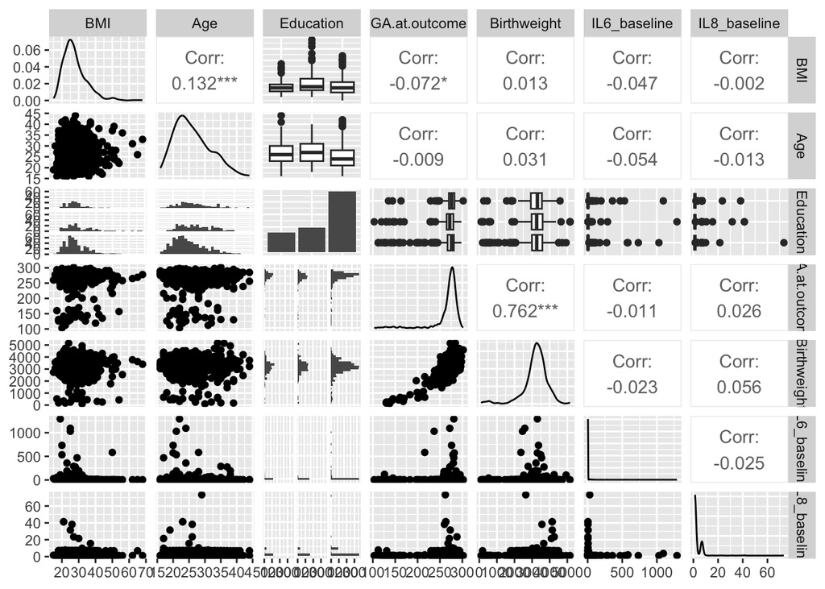

### Correlation between IL-6 and Race, and IL-6 and Age.

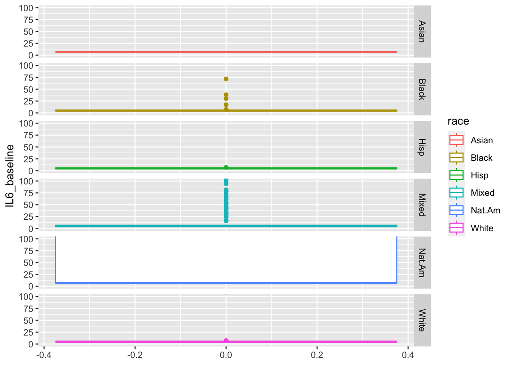

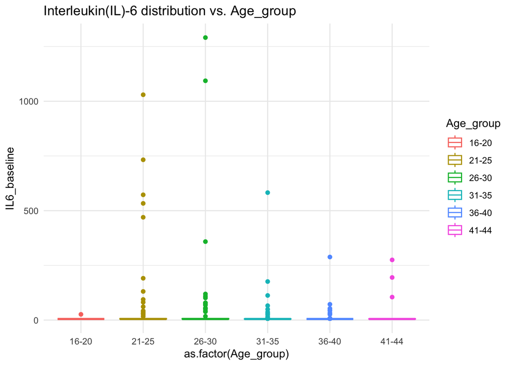

### Checked proportion of Patients Requiring EDC by Age

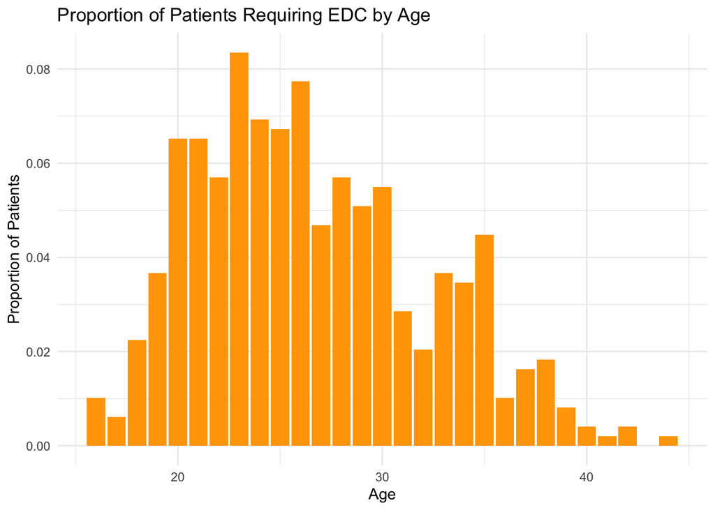

### Checked for linear relationship between age and BMI

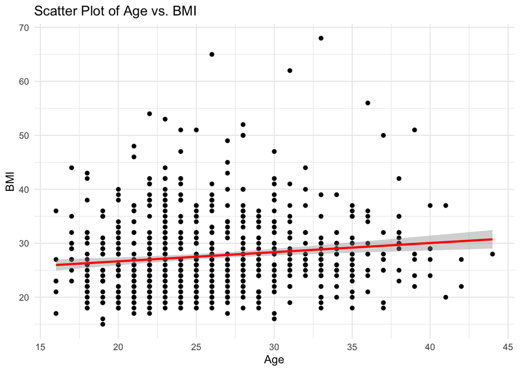

## Analyses

```
## # A tibble: 2 × 6
##   term             df      sumsq   meansq statistic p.value
##   <chr>         <dbl>      <dbl>    <dbl>     <dbl>   <dbl>
## 1 Enroll.Center     3   4237020. 1412340.      3.03  0.0286
## 2 Residuals       816 379968345.  465647.     NA    NA
```

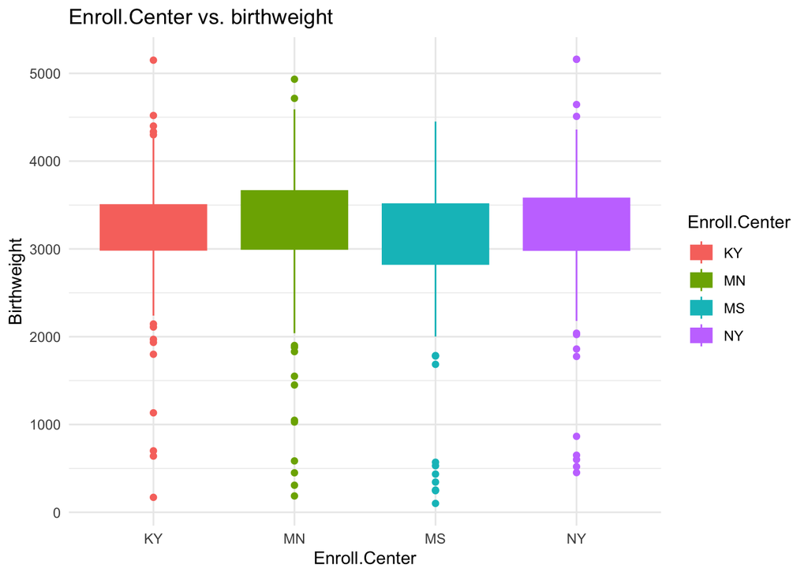

Second, birth outcome was also dependent of BMI of the patient (p=.0458).

```
## # A tibble: 1 × 4
##   statistic p.value parameter method
##       <dbl>   <dbl>     <int> <chr>
## 1      59.8  0.0458        43 Kruskal-Wallis rank sum test
```

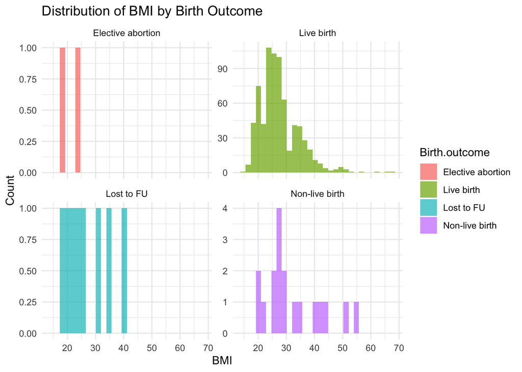

```
## # A tibble: 2 × 6
##   term         df      sumsq  meansq statistic p.value
##   <chr>     <dbl>      <dbl>   <dbl>     <dbl>   <dbl>
## 1 race          5   1285047. 257009.     0.546   0.741
## 2 Residuals   814 382920318. 470418.    NA      NA
```

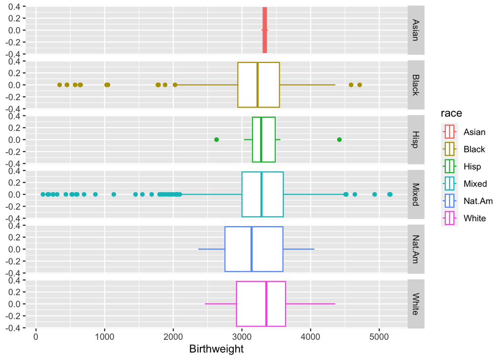

```
## # A tibble: 1 × 10
##   estimate estimate1 estimate2 statistic p.value parameter conf.low conf.high
##      <dbl>     <dbl>     <dbl>     <dbl>   <dbl>     <dbl>    <dbl>     <dbl>
## 1    -27.5     3192.     3219.    -0.574   0.566      800.    -121.      66.5
## # ℹ 2 more variables: method <chr>, alternative <chr>
```

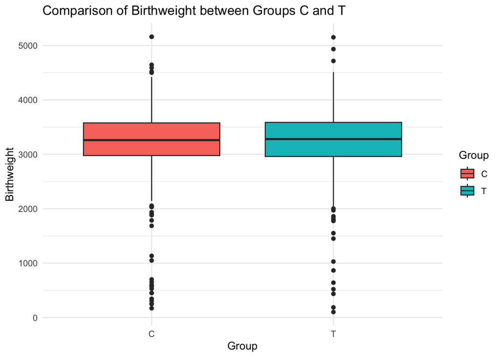